# Final Project EDA

Omkar Purandare

April 6, 2020

# Set Up

```r
# load necessary packages
library(tidyverse)
library(mosaic)
library(rvest)
library(tidyr)
library(dplyr)
library(lubridate)
library(DataComputing)
```

# Guiding Question

What is the relationship between languages spoken in a country to thier social and economic development in 2014?

# Becoming acquainted with your data sources

The data sources we will be using for this project are divded into 2 categories:

- Primary Data
- Other Data Sources

**Primary Data**

The Primary data soruces we will use are:

- List of Number of languages by country from Wikipedia [(link here)](https://en.wikipedia.org/wiki/Number_of_languages_by_country)
  - This data is found on Wikipedia and it controlled by the Wikimedia Foundation Inc
  - This data is collected by the Wikimedia Foundation from bunch of sources as the repsective governments webpage, new articles etc. The data is collected for open source knowledge for the population reading this webpage.
  - This page was last updated on March 27th 2020.
  - The variables I mean to use in thei project are Country or Territory and Established

Heres the data imported into this R notebook

```r
page <- "https://en.wikipedia.org/wiki/Number_of_languages_by_country"
tableList <- page %>%
  read_html() %>%
  html_nodes(css = "table") %>%
  html_table(fill = TRUE)

Languages <- tableList[[1]]

Languages
```

| Rank | Country or territory | Number of living languages | Number of living languages | Number of living languages | Number of living languages | Number of speakers | Number of speakers | Number of speakers |
| --- | --- | --- | --- | --- | --- | --- | --- | --- |
| Rank | Country or territory | Established | Immigrant | Total | Percent[note 1] | Total | Mean | Median |
| 1 | Papua New Guinea | 840 | 0 | 840 | 11.81 | 4,213,381 | 5,040 | 1,315 |
| 2 | Indonesia | 707 | 3 | 710 | 9.98 | 222,191,197 | 315,165 | 3,500 |
| 3 | Nigeria | 517 | 7 | 524 | 7.37 | 163,317,444 | 348,225 | 14,000 |
| 4 | India | 447 | 6 | 453 | 6.37 | 1,257,421,714 | 2,924,237 | 35,000 |
| 5 | China (mainland only) | 302 | 3 | 305 | 4.29 | 1,319,419,348 | 4,472,608 | 27,700 |
| 6 | Mexico | 287 | 5 | 292 | 4.11 | 125,535,200 | 435,886 | 4,730 |
| 7 | Cameroon | 274 | 1 | 275 | 3.87 | 10,228,065 | 38,451 | 10,000 |
| 8 | Australia | 226 | 93 | 319 | 4.49 | 22,693,732 | 72,504 | 10 |
| 9 | United States | 219 | 116 | 335 | 4.71 | 326,756,719 | 999,256 | 12 |

[output cut: 233 more lines]

**Other Data Sources**

The Other data soruces we will use are:

- CountryData
  - This data is from the R package DataComputing
  - This data is collected by the Central Intelligence Agency in USA. The data is collected for open source knowledge for the population reading this webpage and thier own cataloging.
  - This page was last updated in 2014.
  - The variables I mean to use in their project are county and growth, obesity, netUser, cell

Heres the data imported into this R notebook

```r
CountryData
```

| country | area | pop | growth | birth | death | migr | maternal | infant | life | fert | health | HIVrate | HIVpeople | HIVdeath | obesity | underweight | educ | unemploymentYouth | GDP | GDPgrowth | GDPcapita | saving | indProd | labor | unemployment | family | tax | budget | debt | … |
| --- | --- | --- | --- | --- | --- | --- | --- | --- | --- | --- | --- | --- | --- | --- | --- | --- | --- | --- | --- | --- | --- | --- | --- | --- | --- | --- | --- | --- | --- | --- |
| Afghanistan | 652230 | 31822848 | 2.29 | 38.84 | 14.12 | -1.83 | 460 | 117.23 | 50.49 | 5.43 | 9.6 | 0.10 | 4300 | 300 | 2.2 | 32.9 | NA | NA | 4.530e+10 | 3.1 | 1100 | NA | NA | 7512000 | 35.0 | NA | 11.3 | -8.7 | NA | … |
| Akrotiri | 123 | 15700 | NA | NA | NA | NA | NA | NA | NA | NA | NA | NA | NA | NA | NA | NA | NA | NA | NA | NA | NA | NA | NA | NA | NA | NA | NA | NA | NA | … |
| Albania | 28748 | 3020209 | 0.30 | 12.73 | 6.47 | -3.31 | 27 | 13.19 | 77.96 | 1.50 | 6.3 | NA | NA | NA | 21.3 | 6.3 | 3.3 | 22.5 | 2.834e+10 | 0.7 | 10700 | 14.1 | 3.1 | 1098000 | 16.9 | 34.5 | 24.0 | -6.1 | 70.5 | … |
| Algeria | 2381741 | 38813722 | 1.88 | 23.99 | 4.31 | -0.93 | 97 | 21.76 | 76.39 | 2.78 | 3.9 | 0.10 | 18000 | 1000 | 16.0 | 3.7 | 4.3 | 28.4 | 2.847e+11 | 3.1 | 7500 | 45.5 | 2.5 | 11150000 | 10.3 | 35.3 | 37.3 | -2.3 | 13.2 | … |
| American Samoa | 199 | 54517 | -0.35 | 22.87 | 4.68 | -21.64 | NA | 8.92 | 74.91 | 2.98 | NA | NA | NA | NA | 74.6 | NA | NA | NA | 5.753e+08 | 3.0 | 8000 | NA | NA | 17630 | 29.8 | NA | 33.6 | -6.1 | NA | … |
| Andorra | 468 | 85458 | 0.17 | 8.48 | 6.82 | 0.00 | NA | 3.69 | 82.65 | 1.38 | 7.2 | NA | NA | NA | 25.2 | NA | NA | NA | 3.163e+09 | -1.6 | 37200 | NA | NA | 36060 | 4.0 | NA | 21.4 | -0.3 | 41.1 | … |
| Angola | 1246700 | 19088106 | 2.78 | 38.97 | 11.67 | 0.47 | 450 | 79.99 | 55.29 | 5.43 | 3.5 | 2.30 | 248800 | 12600 | 6.4 | 15.6 | 3.5 | NA | 1.318e+11 | 5.6 | 6300 | 19.1 | 5.5 | 9018000 | NA | NA | 42.5 | 3.4 | 14.7 | … |
| Anguilla | 91 | 16086 | 2.06 | 12.68 | 4.54 | 12.43 | NA | 3.40 | 81.20 | 1.75 | NA | NA | NA | NA | NA | NA | 2.8 | NA | 1.754e+08 | -8.5 | 12200 | NA | 2.0 | 6049 | 8.0 | NA | 39.6 | -5.0 | 20.0 | … |
| Antarctica | NA | NA | NA | NA | NA | NA | NA | NA | NA | NA | NA | NA | NA | NA | NA | NA | NA | NA | NA | NA | NA | NA | NA | NA | NA | NA | NA | NA | NA | … |
| Antigua and Barbuda | 443 | 91295 | 1.25 | 15.94 | 5.70 | 2.23 | NA | 13.29 | 76.12 | 2.03 | 5.9 | NA | NA | NA | 25.6 | NA | 2.4 | 19.9 | 1.610e+09 | 1.7 | 18400 | 18.0 | 1.0 | 30000 | 11.0 | NA | 19.6 | -0.8 | 89.0 | … |

[output cut: 246 more lines]

# Explore intuition related to the research question

Data Wrangling for Languages

```r
names(Languages)[c(2,3,4,5,6,7,8,9)] <- c("country", "count_lang","immigrant","total","percent","t", "mean", "median")
```

```r
Languages <-
  Languages %>%
  filter(row_number() > 1) %>%
  select(country,count_lang) %>%
  mutate(count_lang = as.numeric(count_lang))
```

Joining both Datasets

```r
Hypo <-
  Languages %>%
  left_join(CountryData %>% select(country,growth, obesity, cell), by = c("country" = "country"))

Hypo
```

| country | count_lang | growth | obesity | cell |
| --- | --- | --- | --- | --- |
| Papua New Guinea | 840 | 1.84 | 16.2 | 2709000 |
| Indonesia | 707 | 0.95 | 4.8 | 281960000 |
| Nigeria | 517 | 2.47 | 6.5 | 112780000 |
| India | 447 | 1.25 | 1.9 | 893862000 |
| China (mainland only) | 302 | NA | NA | NA |
| Mexico | 287 | 1.21 | 32.1 | 100786000 |
| Cameroon | 274 | 2.60 | 10.3 | 13100000 |
| Australia | 226 | 1.09 | 26.8 | 24400000 |
| United States | 219 | 0.77 | 33.0 | 310000000 |
| Brazil | 217 | 0.80 | 18.8 | 248324000 |

[output cut: 232 more lines]

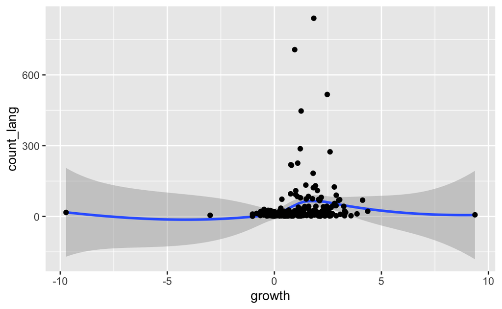

```r
Hypo %>%
  mutate(country = reorder(country, count_lang)) %>%
  ggplot(aes(x=growth, y= count_lang)) + stat_smooth() + geom_point()
```

Seing the confidence interval being large we can see there is not much of a relationship between the two varaibles

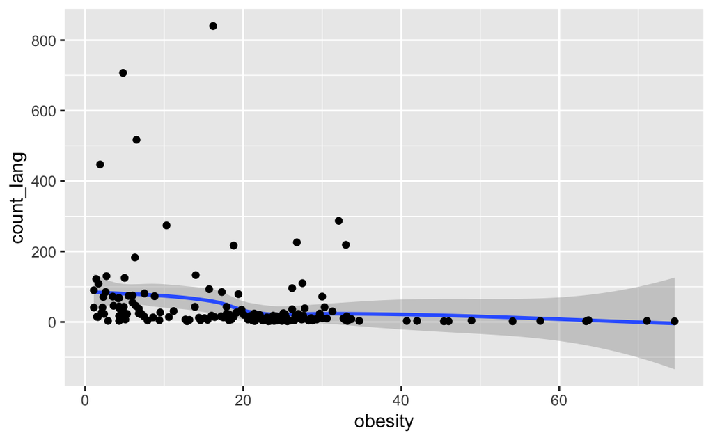

```r
Hypo %>%
  mutate(country = reorder(country, count_lang)) %>%
  ggplot(aes(x=obesity, y= count_lang)) + stat_smooth() + geom_point()
```

We can see that the higher the languages spoken in country the lower the obesetiy count is for that country